# Risk Factor Analysis

## Outcome Variable

**Outcome Variable:** wast_rec90d

## Predictor Variables

**Intervention Variable:** mage

**Adjustment Set:**

- arm
- meducyrs
- feducyrs
- hhwealth_quart
- W_mhtcm
- W_nrooms
- W_nchldlt5
- impfloor
- impsan
- delta_meducyrs
- delta_feducyrs
- delta_hhwealth_quart
- delta_W_mhtcm
- delta_W_nrooms
- delta_W_nchldlt5
- delta_impfloor
- delta_impsan

## Stratifying Variables

The analysis was stratified on these variable(s):

- agecat
- studyid
- country

## Data Summary

| agecat | studyid | country | mage | wast_rec90d | n_cell | n |
| --- | --- | --- | --- | --- | --- | --- |
| 0-24 months | ki0047075b-MAL-ED | BANGLADESH | <25 | 0 | 18 | 124 |
| 0-24 months | ki0047075b-MAL-ED | BANGLADESH | <25 | 1 | 36 | 124 |
| 0-24 months | ki0047075b-MAL-ED | BANGLADESH | [25-30) | 0 | 14 | 124 |
| 0-24 months | ki0047075b-MAL-ED | BANGLADESH | [25-30) | 1 | 27 | 124 |
| 0-24 months | ki0047075b-MAL-ED | BANGLADESH | >=30 | 0 | 13 | 124 |
| 0-24 months | ki0047075b-MAL-ED | BANGLADESH | >=30 | 1 | 16 | 124 |
| 0-24 months | ki0047075b-MAL-ED | BRAZIL | <25 | 0 | 0 | 23 |
| 0-24 months | ki0047075b-MAL-ED | BRAZIL | <25 | 1 | 8 | 23 |
| 0-24 months | ki0047075b-MAL-ED | BRAZIL | [25-30) | 0 | 3 | 23 |
| 0-24 months | ki0047075b-MAL-ED | BRAZIL | [25-30) | 1 | 7 | 23 |
| 0-24 months | ki0047075b-MAL-ED | BRAZIL | >=30 | 0 | 3 | 23 |
| 0-24 months | ki0047075b-MAL-ED | BRAZIL | >=30 | 1 | 2 | 23 |
| 0-24 months | ki0047075b-MAL-ED | INDIA | <25 | 0 | 44 | 177 |
| 0-24 months | ki0047075b-MAL-ED | INDIA | <25 | 1 | 59 | 177 |
| 0-24 months | ki0047075b-MAL-ED | INDIA | [25-30) | 0 | 26 | 177 |
| 0-24 months | ki0047075b-MAL-ED | INDIA | [25-30) | 1 | 41 | 177 |
| 0-24 months | ki0047075b-MAL-ED | INDIA | >=30 | 0 | 1 | 177 |
| 0-24 months | ki0047075b-MAL-ED | INDIA | >=30 | 1 | 6 | 177 |
| 0-24 months | ki0047075b-MAL-ED | NEPAL | <25 | 0 | 9 | 93 |
| 0-24 months | ki0047075b-MAL-ED | NEPAL | <25 | 1 | 26 | 93 |
| 0-24 months | ki0047075b-MAL-ED | NEPAL | [25-30) | 0 | 10 | 93 |
| 0-24 months | ki0047075b-MAL-ED | NEPAL | [25-30) | 1 | 35 | 93 |
| 0-24 months | ki0047075b-MAL-ED | NEPAL | >=30 | 0 | 1 | 93 |
| 0-24 months | ki0047075b-MAL-ED | NEPAL | >=30 | 1 | 12 | 93 |
| 0-24 months | ki0047075b-MAL-ED | PERU | <25 | 0 | 5 | 34 |
| 0-24 months | ki0047075b-MAL-ED | PERU | <25 | 1 | 17 | 34 |
| 0-24 months | ki0047075b-MAL-ED | PERU | [25-30) | 0 | 0 | 34 |
| 0-24 months | ki0047075b-MAL-ED | PERU | [25-30) | 1 | 6 | 34 |
| 0-24 months | ki0047075b-MAL-ED | PERU | >=30 | 0 | 1 | 34 |
| 0-24 months | ki0047075b-MAL-ED | PERU | >=30 | 1 | 5 | 34 |

[output cut: 450 more lines]

The following strata were considered:

- agecat: 0-24 months, studyid: ki0047075b-MAL-ED, country: BANGLADESH
- agecat: 0-24 months, studyid: ki0047075b-MAL-ED, country: BRAZIL
- agecat: 0-24 months, studyid: ki0047075b-MAL-ED, country: INDIA
- agecat: 0-24 months, studyid: ki0047075b-MAL-ED, country: NEPAL
- agecat: 0-24 months, studyid: ki0047075b-MAL-ED, country: PERU
- agecat: 0-24 months, studyid: ki0047075b-MAL-ED, country: SOUTH AFRICA
- agecat: 0-24 months, studyid: ki0047075b-MAL-ED, country: TANZANIA, UNITED REPUBLIC OF
- agecat: 0-24 months, studyid: ki1000108-CMC-V-BCS-2002, country: INDIA
- agecat: 0-24 months, studyid: ki1000108-IRC, country: INDIA
- agecat: 0-24 months, studyid: ki1000109-EE, country: PAKISTAN
- agecat: 0-24 months, studyid: ki1000304b-SAS-CompFeed, country: INDIA
- agecat: 0-24 months, studyid: ki1000304b-SAS-FoodSuppl, country: INDIA
- agecat: 0-24 months, studyid: ki1017093-NIH-Birth, country: BANGLADESH
- agecat: 0-24 months, studyid: ki1017093b-PROVIDE, country: BANGLADESH
- agecat: 0-24 months, studyid: ki1017093c-NIH-Crypto, country: BANGLADESH
- agecat: 0-24 months, studyid: ki1066203-TanzaniaChild2, country: TANZANIA, UNITED REPUBLIC OF
- agecat: 0-24 months, studyid: ki1101329-Keneba, country: GAMBIA
- agecat: 0-24 months, studyid: ki1112895-Guatemala BSC, country: GUATEMALA
- agecat: 0-24 months, studyid: ki1112895-iLiNS-Zinc, country: BURKINA FASO
- agecat: 0-24 months, studyid: ki1113344-GMS-Nepal, country: NEPAL
- agecat: 0-24 months, studyid: ki1119695-PROBIT, country: BELARUS
- agecat: 0-24 months, studyid: ki1126311-ZVITAMBO, country: ZIMBABWE
- agecat: 0-24 months, studyid: ki1135781-COHORTS, country: GUATEMALA
- agecat: 0-24 months, studyid: ki1135781-COHORTS, country: INDIA
- agecat: 0-24 months, studyid: ki1135781-COHORTS, country: PHILIPPINES
- agecat: 0-24 months, studyid: ki1148112-LCNI-5, country: MALAWI
- agecat: 0-24 months, studyid: kiGH5241-JiVitA-3, country: BANGLADESH
- agecat: 0-6 months, studyid: ki0047075b-MAL-ED, country: BANGLADESH
- agecat: 0-6 months, studyid: ki0047075b-MAL-ED, country: BRAZIL
- agecat: 0-6 months, studyid: ki0047075b-MAL-ED, country: INDIA
- agecat: 0-6 months, studyid: ki0047075b-MAL-ED, country: NEPAL
- agecat: 0-6 months, studyid: ki0047075b-MAL-ED, country: PERU
- agecat: 0-6 months, studyid: ki0047075b-MAL-ED, country: SOUTH AFRICA
- agecat: 0-6 months, studyid: ki0047075b-MAL-ED, country: TANZANIA, UNITED REPUBLIC OF
- agecat: 0-6 months, studyid: ki1000108-CMC-V-BCS-2002, country: INDIA
- agecat: 0-6 months, studyid: ki1000108-IRC, country: INDIA
- agecat: 0-6 months, studyid: ki1000109-EE, country: PAKISTAN
- agecat: 0-6 months, studyid: ki1000304b-SAS-CompFeed, country: INDIA
- agecat: 0-6 months, studyid: ki1000304b-SAS-FoodSuppl, country: INDIA
- agecat: 0-6 months, studyid: ki1017093-NIH-Birth, country: BANGLADESH
- agecat: 0-6 months, studyid: ki1017093b-PROVIDE, country: BANGLADESH
- agecat: 0-6 months, studyid: ki1017093c-NIH-Crypto, country: BANGLADESH
- agecat: 0-6 months, studyid: ki1066203-TanzaniaChild2, country: TANZANIA, UNITED REPUBLIC OF
- agecat: 0-6 months, studyid: ki1101329-Keneba, country: GAMBIA
- agecat: 0-6 months, studyid: ki1112895-Guatemala BSC, country: GUATEMALA
- agecat: 0-6 months, studyid: ki1113344-GMS-Nepal, country: NEPAL
- agecat: 0-6 months, studyid: ki1119695-PROBIT, country: BELARUS
- agecat: 0-6 months, studyid: ki1126311-ZVITAMBO, country: ZIMBABWE
- agecat: 0-6 months, studyid: ki1135781-COHORTS, country: GUATEMALA
- agecat: 0-6 months, studyid: ki1135781-COHORTS, country: INDIA
- agecat: 0-6 months, studyid: ki1135781-COHORTS, country: PHILIPPINES
- agecat: 0-6 months, studyid: ki1148112-LCNI-5, country: MALAWI
- agecat: 0-6 months, studyid: kiGH5241-JiVitA-3, country: BANGLADESH
- agecat: 6-24 months, studyid: ki0047075b-MAL-ED, country: BANGLADESH
- agecat: 6-24 months, studyid: ki0047075b-MAL-ED, country: BRAZIL
- agecat: 6-24 months, studyid: ki0047075b-MAL-ED, country: INDIA
- agecat: 6-24 months, studyid: ki0047075b-MAL-ED, country: NEPAL
- agecat: 6-24 months, studyid: ki0047075b-MAL-ED, country: PERU
- agecat: 6-24 months, studyid: ki0047075b-MAL-ED, country: SOUTH AFRICA
- agecat: 6-24 months, studyid: ki0047075b-MAL-ED, country: TANZANIA, UNITED REPUBLIC OF
- agecat: 6-24 months, studyid: ki1000108-CMC-V-BCS-2002, country: INDIA
- agecat: 6-24 months, studyid: ki1000108-IRC, country: INDIA
- agecat: 6-24 months, studyid: ki1000109-EE, country: PAKISTAN
- agecat: 6-24 months, studyid: ki1000304b-SAS-CompFeed, country: INDIA
- agecat: 6-24 months, studyid: ki1000304b-SAS-FoodSuppl, country: INDIA
- agecat: 6-24 months, studyid: ki1017093-NIH-Birth, country: BANGLADESH
- agecat: 6-24 months, studyid: ki1017093b-PROVIDE, country: BANGLADESH
- agecat: 6-24 months, studyid: ki1017093c-NIH-Crypto, country: BANGLADESH
- agecat: 6-24 months, studyid: ki1066203-TanzaniaChild2, country: TANZANIA, UNITED REPUBLIC OF
- agecat: 6-24 months, studyid: ki1101329-Keneba, country: GAMBIA
- agecat: 6-24 months, studyid: ki1112895-Guatemala BSC, country: GUATEMALA
- agecat: 6-24 months, studyid: ki1112895-iLiNS-Zinc, country: BURKINA FASO
- agecat: 6-24 months, studyid: ki1113344-GMS-Nepal, country: NEPAL
- agecat: 6-24 months, studyid: ki1119695-PROBIT, country: BELARUS
- agecat: 6-24 months, studyid: ki1126311-ZVITAMBO, country: ZIMBABWE
- agecat: 6-24 months, studyid: ki1135781-COHORTS, country: GUATEMALA
- agecat: 6-24 months, studyid: ki1135781-COHORTS, country: INDIA
- agecat: 6-24 months, studyid: ki1135781-COHORTS, country: PHILIPPINES
- agecat: 6-24 months, studyid: ki1148112-LCNI-5, country: MALAWI
- agecat: 6-24 months, studyid: kiGH5241-JiVitA-3, country: BANGLADESH

### Dropped Strata

Some strata were dropped due to rare outcomes:

- agecat: 0-24 months, studyid: ki0047075b-MAL-ED, country: BRAZIL
- agecat: 0-24 months, studyid: ki0047075b-MAL-ED, country: INDIA
- agecat: 0-24 months, studyid: ki0047075b-MAL-ED, country: NEPAL
- agecat: 0-24 months, studyid: ki0047075b-MAL-ED, country: PERU
- agecat: 0-24 months, studyid: ki0047075b-MAL-ED, country: SOUTH AFRICA
- agecat: 0-24 months, studyid: ki0047075b-MAL-ED, country: TANZANIA, UNITED REPUBLIC OF
- agecat: 0-24 months, studyid: ki1000304b-SAS-FoodSuppl, country: INDIA
- agecat: 0-24 months, studyid: ki1112895-Guatemala BSC, country: GUATEMALA
- agecat: 0-24 months, studyid: ki1148112-LCNI-5, country: MALAWI
- agecat: 0-6 months, studyid: ki0047075b-MAL-ED, country: BANGLADESH
- agecat: 0-6 months, studyid: ki0047075b-MAL-ED, country: BRAZIL
- agecat: 0-6 months, studyid: ki0047075b-MAL-ED, country: INDIA
- agecat: 0-6 months, studyid: ki0047075b-MAL-ED, country: NEPAL
- agecat: 0-6 months, studyid: ki0047075b-MAL-ED, country: PERU
- agecat: 0-6 months, studyid: ki0047075b-MAL-ED, country: SOUTH AFRICA
- agecat: 0-6 months, studyid: ki0047075b-MAL-ED, country: TANZANIA, UNITED REPUBLIC OF
- agecat: 0-6 months, studyid: ki1000109-EE, country: PAKISTAN
- agecat: 0-6 months, studyid: ki1000304b-SAS-FoodSuppl, country: INDIA
- agecat: 0-6 months, studyid: ki1017093c-NIH-Crypto, country: BANGLADESH
- agecat: 0-6 months, studyid: ki1112895-Guatemala BSC, country: GUATEMALA
- agecat: 0-6 months, studyid: ki1148112-LCNI-5, country: MALAWI
- agecat: 6-24 months, studyid: ki0047075b-MAL-ED, country: BRAZIL
- agecat: 6-24 months, studyid: ki0047075b-MAL-ED, country: INDIA
- agecat: 6-24 months, studyid: ki0047075b-MAL-ED, country: NEPAL
- agecat: 6-24 months, studyid: ki0047075b-MAL-ED, country: PERU
- agecat: 6-24 months, studyid: ki0047075b-MAL-ED, country: SOUTH AFRICA
- agecat: 6-24 months, studyid: ki0047075b-MAL-ED, country: TANZANIA, UNITED REPUBLIC OF
- agecat: 6-24 months, studyid: ki1000108-IRC, country: INDIA
- agecat: 6-24 months, studyid: ki1000304b-SAS-FoodSuppl, country: INDIA
- agecat: 6-24 months, studyid: ki1017093c-NIH-Crypto, country: BANGLADESH
- agecat: 6-24 months, studyid: ki1112895-Guatemala BSC, country: GUATEMALA
- agecat: 6-24 months, studyid: ki1135781-COHORTS, country: GUATEMALA
- agecat: 6-24 months, studyid: ki1135781-COHORTS, country: INDIA
- agecat: 6-24 months, studyid: ki1148112-LCNI-5, country: MALAWI
- agecat: 6-24 months, studyid: kiGH5241-JiVitA-3, country: BANGLADESH

## Methods Detail

We’re interested in the causal parameters $E[Y_a]$ for all values of $a \in \mathcal{A}$. These parameters represent the mean outcome if, possibly contrary to fact, we intervened to set all units to have $A=a$. Under the randomization and positivity assumptions, these are identified by the statistical parameters $\psi_a=E_W[E_{Y|A,W}(Y|A=a,W)]$. In addition, we’re interested in the mean of $Y$, $E[Y]$ under no intervention (the observed mean). We will estimate these parameters by using SuperLearner to fit the relevant likelihood factors – $E_{Y|A,W}(Y|A=a,W)$ and $p(A=a|W)$, and then updating our likelihood fit using a joint TMLE.

For unadjusted analyses ($W=\{\}$), initial likelihoods were estimated using Lrnr_glm to estimate the simple $E(Y|A)$ and Lrnr_mean to estimate $p(A)$. For adjusted analyses, a small library containing Lrnr_glmnet, Lrnr_xgboost, and Lrnr_mean was used.

Having estimated these parameters, we will then use the delta method to estimate relative risks and attributable risks relative to a prespecified baseline level of $A$.

# Results Detail

## Results Plots

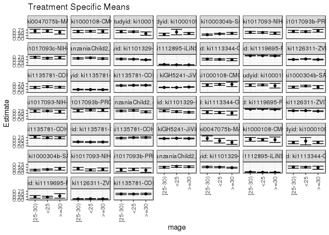

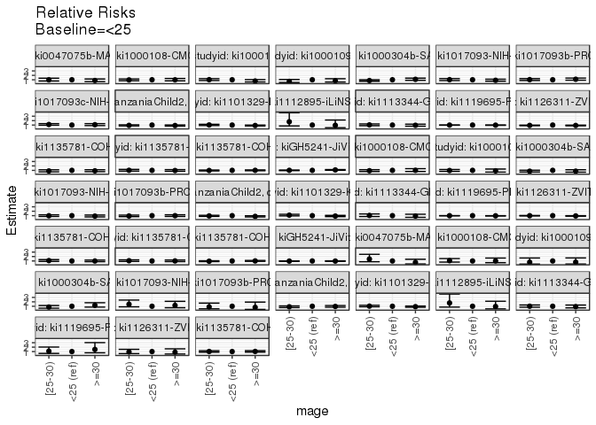

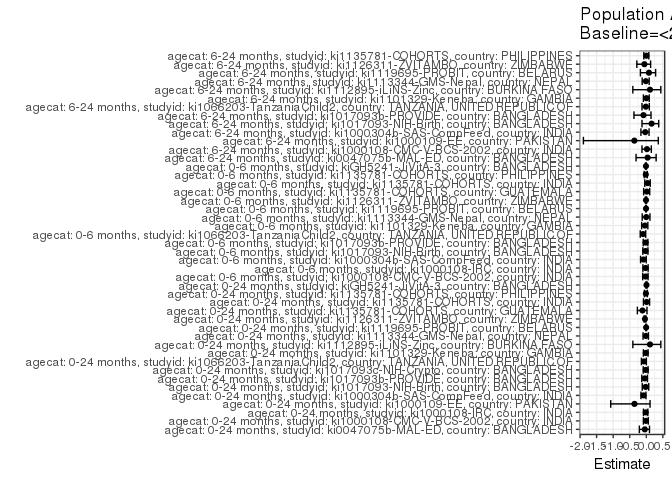

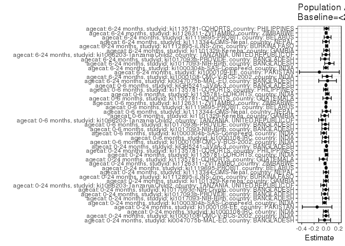

## Results Table

### Parameter: TSM

| agecat | studyid | country | intervention_level | baseline_level | estimate | ci_lower | ci_upper |
| --- | --- | --- | --- | --- | --- | --- | --- |
| 0-24 months | ki0047075b-MAL-ED | BANGLADESH | <25 | NA | 0.6660630 | 0.5411283 | 0.7909978 |
| 0-24 months | ki0047075b-MAL-ED | BANGLADESH | [25-30) | NA | 0.6586464 | 0.4952639 | 0.8220290 |
| 0-24 months | ki0047075b-MAL-ED | BANGLADESH | >=30 | NA | 0.5522081 | 0.3883612 | 0.7160551 |
| 0-24 months | ki1000108-CMC-V-BCS-2002 | INDIA | <25 | NA | 0.6387435 | 0.5643906 | 0.7130963 |
| 0-24 months | ki1000108-CMC-V-BCS-2002 | INDIA | [25-30) | NA | 0.6185567 | 0.5162792 | 0.7208342 |
| 0-24 months | ki1000108-CMC-V-BCS-2002 | INDIA | >=30 | NA | 0.6315789 | 0.4821442 | 0.7810137 |
| 0-24 months | ki1000108-IRC | INDIA | <25 | NA | 0.6002964 | 0.5369886 | 0.6636041 |
| 0-24 months | ki1000108-IRC | INDIA | [25-30) | NA | 0.6126001 | 0.5082377 | 0.7169626 |
| 0-24 months | ki1000108-IRC | INDIA | >=30 | NA | 0.4333539 | 0.2815788 | 0.5851290 |
| 0-24 months | ki1000109-EE | PAKISTAN | <25 | NA | 0.5714286 | 0.3275171 | 0.8153400 |
| 0-24 months | ki1000109-EE | PAKISTAN | [25-30) | NA | 0.3626374 | 0.2548744 | 0.4704003 |
| 0-24 months | ki1000109-EE | PAKISTAN | >=30 | NA | 0.4429530 | 0.3553497 | 0.5305564 |
| 0-24 months | ki1000304b-SAS-CompFeed | INDIA | <25 | NA | 0.4126233 | 0.3671229 | 0.4581236 |
| 0-24 months | ki1000304b-SAS-CompFeed | INDIA | [25-30) | NA | 0.3387640 | 0.2810713 | 0.3964566 |
| 0-24 months | ki1000304b-SAS-CompFeed | INDIA | >=30 | NA | 0.4528395 | 0.3678853 | 0.5377937 |
| 0-24 months | ki1017093-NIH-Birth | BANGLADESH | <25 | NA | 0.5305226 | 0.4583907 | 0.6026544 |
| 0-24 months | ki1017093-NIH-Birth | BANGLADESH | [25-30) | NA | 0.5430733 | 0.4528143 | 0.6333323 |
| 0-24 months | ki1017093-NIH-Birth | BANGLADESH | >=30 | NA | 0.4654846 | 0.3655854 | 0.5653838 |
| 0-24 months | ki1017093b-PROVIDE | BANGLADESH | <25 | NA | 0.6102538 | 0.5333711 | 0.6871366 |
| 0-24 months | ki1017093b-PROVIDE | BANGLADESH | [25-30) | NA | 0.6275678 | 0.5280028 | 0.7271329 |
| 0-24 months | ki1017093b-PROVIDE | BANGLADESH | >=30 | NA | 0.6821731 | 0.5640013 | 0.8003448 |
| 0-24 months | ki1017093c-NIH-Crypto | BANGLADESH | <25 | NA | 0.6341919 | 0.5620477 | 0.7063362 |
| 0-24 months | ki1017093c-NIH-Crypto | BANGLADESH | [25-30) | NA | 0.7154479 | 0.6312019 | 0.7996938 |
| 0-24 months | ki1017093c-NIH-Crypto | BANGLADESH | >=30 | NA | 0.6848268 | 0.5659706 | 0.8036829 |
| 0-24 months | ki1066203-TanzaniaChild2 | TANZANIA, UNITED REPUBLIC OF | <25 | NA | 0.6706981 | 0.6124334 | 0.7289627 |
| 0-24 months | ki1066203-TanzaniaChild2 | TANZANIA, UNITED REPUBLIC OF | [25-30) | NA | 0.6216879 | 0.5621075 | 0.6812683 |
| 0-24 months | ki1066203-TanzaniaChild2 | TANZANIA, UNITED REPUBLIC OF | >=30 | NA | 0.5992287 | 0.5346088 | 0.6638486 |
| 0-24 months | ki1101329-Keneba | GAMBIA | <25 | NA | 0.5498863 | 0.5036318 | 0.5961407 |
| 0-24 months | ki1101329-Keneba | GAMBIA | [25-30) | NA | 0.5645470 | 0.5070264 | 0.6220677 |
| 0-24 months | ki1101329-Keneba | GAMBIA | >=30 | NA | 0.4930619 | 0.4545089 | 0.5316149 |

[output cut: 105 more lines]

### Parameter: E(Y)

| agecat | studyid | country | intervention_level | baseline_level | estimate | ci_lower | ci_upper |
| --- | --- | --- | --- | --- | --- | --- | --- |
| 0-24 months | ki0047075b-MAL-ED | BANGLADESH | NA | NA | 0.6370968 | 0.5511492 | 0.7230443 |
| 0-24 months | ki1000108-CMC-V-BCS-2002 | INDIA | NA | NA | 0.6319018 | 0.5759256 | 0.6878781 |
| 0-24 months | ki1000108-IRC | INDIA | NA | NA | 0.5898734 | 0.5376978 | 0.6420491 |
| 0-24 months | ki1000109-EE | PAKISTAN | NA | NA | 0.4212598 | 0.3553979 | 0.4871218 |
| 0-24 months | ki1000304b-SAS-CompFeed | INDIA | NA | NA | 0.3808354 | 0.3457640 | 0.4159068 |
| 0-24 months | ki1017093-NIH-Birth | BANGLADESH | NA | NA | 0.5202864 | 0.4695109 | 0.5710618 |
| 0-24 months | ki1017093b-PROVIDE | BANGLADESH | NA | NA | 0.5830619 | 0.5262762 | 0.6398476 |
| 0-24 months | ki1017093c-NIH-Crypto | BANGLADESH | NA | NA | 0.6237942 | 0.5698223 | 0.6777662 |
| 0-24 months | ki1066203-TanzaniaChild2 | TANZANIA, UNITED REPUBLIC OF | NA | NA | 0.6267606 | 0.5890263 | 0.6644948 |
| 0-24 months | ki1101329-Keneba | GAMBIA | NA | NA | 0.5416116 | 0.5143001 | 0.5689232 |
| 0-24 months | ki1112895-iLiNS-Zinc | BURKINA FASO | NA | NA | 0.0435339 | 0.0292984 | 0.0577695 |
| 0-24 months | ki1113344-GMS-Nepal | NEPAL | NA | NA | 0.5222816 | 0.4773852 | 0.5671781 |
| 0-24 months | ki1119695-PROBIT | BELARUS | NA | NA | 0.8612051 | 0.8511051 | 0.8713052 |
| 0-24 months | ki1126311-ZVITAMBO | ZIMBABWE | NA | NA | 0.5442043 | 0.5277100 | 0.5606986 |
| 0-24 months | ki1135781-COHORTS | GUATEMALA | NA | NA | 0.4421053 | 0.3904403 | 0.4937702 |
| 0-24 months | ki1135781-COHORTS | INDIA | NA | NA | 0.2355670 | 0.2165976 | 0.2545364 |
| 0-24 months | ki1135781-COHORTS | PHILIPPINES | NA | NA | 0.6068680 | 0.5823645 | 0.6313715 |
| 0-24 months | kiGH5241-JiVitA-3 | BANGLADESH | NA | NA | 0.4225334 | 0.4114140 | 0.4336527 |
| 0-6 months | ki1000108-CMC-V-BCS-2002 | INDIA | NA | NA | 0.6748768 | 0.6092233 | 0.7405304 |
| 0-6 months | ki1000108-IRC | INDIA | NA | NA | 0.6375000 | 0.5751450 | 0.6998550 |
| 0-6 months | ki1000304b-SAS-CompFeed | INDIA | NA | NA | 0.5131965 | 0.4596632 | 0.5667297 |
| 0-6 months | ki1017093-NIH-Birth | BANGLADESH | NA | NA | 0.7130045 | 0.6535890 | 0.7724200 |
| 0-6 months | ki1017093b-PROVIDE | BANGLADESH | NA | NA | 0.7880435 | 0.7295878 | 0.8464992 |
| 0-6 months | ki1066203-TanzaniaChild2 | TANZANIA, UNITED REPUBLIC OF | NA | NA | 0.7020649 | 0.6526590 | 0.7514708 |
| 0-6 months | ki1101329-Keneba | GAMBIA | NA | NA | 0.6352657 | 0.5887450 | 0.6817864 |
| 0-6 months | ki1113344-GMS-Nepal | NEPAL | NA | NA | 0.5833333 | 0.5108676 | 0.6557991 |
| 0-6 months | ki1119695-PROBIT | BELARUS | NA | NA | 0.8855266 | 0.8758983 | 0.8951550 |
| 0-6 months | ki1126311-ZVITAMBO | ZIMBABWE | NA | NA | 0.7443159 | 0.7272505 | 0.7613813 |
| 0-6 months | ki1135781-COHORTS | GUATEMALA | NA | NA | 0.7476636 | 0.6894668 | 0.8058603 |
| 0-6 months | ki1135781-COHORTS | INDIA | NA | NA | 0.3581505 | 0.3318331 | 0.3844678 |
| 0-6 months | ki1135781-COHORTS | PHILIPPINES | NA | NA | 0.7367021 | 0.7051294 | 0.7682749 |
| 0-6 months | kiGH5241-JiVitA-3 | BANGLADESH | NA | NA | 0.6753219 | 0.6619872 | 0.6886567 |
| 6-24 months | ki0047075b-MAL-ED | BANGLADESH | NA | NA | 0.4838710 | 0.3544124 | 0.6133295 |
| 6-24 months | ki1000108-CMC-V-BCS-2002 | INDIA | NA | NA | 0.5609756 | 0.4682842 | 0.6536670 |
| 6-24 months | ki1000109-EE | PAKISTAN | NA | NA | 0.3150685 | 0.2385846 | 0.3915524 |
| 6-24 months | ki1000304b-SAS-CompFeed | INDIA | NA | NA | 0.2854123 | 0.2436284 | 0.3271961 |
| 6-24 months | ki1017093-NIH-Birth | BANGLADESH | NA | NA | 0.3010204 | 0.2354283 | 0.3666125 |
| 6-24 months | ki1017093b-PROVIDE | BANGLADESH | NA | NA | 0.2764228 | 0.1950773 | 0.3577682 |
| 6-24 months | ki1066203-TanzaniaChild2 | TANZANIA, UNITED REPUBLIC OF | NA | NA | 0.5579515 | 0.5056058 | 0.6102972 |
| 6-24 months | ki1101329-Keneba | GAMBIA | NA | NA | 0.5063636 | 0.4748679 | 0.5378594 |
| 6-24 months | ki1112895-iLiNS-Zinc | BURKINA FASO | NA | NA | 0.0435339 | 0.0292984 | 0.0577695 |
| 6-24 months | ki1113344-GMS-Nepal | NEPAL | NA | NA | 0.4934383 | 0.4388573 | 0.5480193 |
| 6-24 months | ki1119695-PROBIT | BELARUS | NA | NA | 0.2440476 | 0.1791134 | 0.3089818 |
| 6-24 months | ki1126311-ZVITAMBO | ZIMBABWE | NA | NA | 0.0691288 | 0.0539734 | 0.0842842 |
| 6-24 months | ki1135781-COHORTS | PHILIPPINES | NA | NA | 0.5026681 | 0.4688378 | 0.5364984 |

### Parameter: RR

| agecat | studyid | country | intervention_level | baseline_level | estimate | ci_lower | ci_upper |
| --- | --- | --- | --- | --- | --- | --- | --- |
| 0-24 months | ki0047075b-MAL-ED | BANGLADESH | <25 | <25 | 1.0000000 | 1.0000000 | 1.0000000 |
| 0-24 months | ki0047075b-MAL-ED | BANGLADESH | [25-30) | <25 | 0.9888650 | 0.7247068 | 1.3493099 |
| 0-24 months | ki0047075b-MAL-ED | BANGLADESH | >=30 | <25 | 0.8290629 | 0.5834002 | 1.1781711 |
| 0-24 months | ki1000108-CMC-V-BCS-2002 | INDIA | <25 | <25 | 1.0000000 | 1.0000000 | 1.0000000 |
| 0-24 months | ki1000108-CMC-V-BCS-2002 | INDIA | [25-30) | <25 | 0.9683961 | 0.7911341 | 1.1853757 |
| 0-24 months | ki1000108-CMC-V-BCS-2002 | INDIA | >=30 | <25 | 0.9887834 | 0.7595844 | 1.2871415 |
| 0-24 months | ki1000108-IRC | INDIA | <25 | <25 | 1.0000000 | 1.0000000 | 1.0000000 |
| 0-24 months | ki1000108-IRC | INDIA | [25-30) | <25 | 1.0204962 | 0.8351657 | 1.2469531 |
| 0-24 months | ki1000108-IRC | INDIA | >=30 | <25 | 0.7219000 | 0.5008606 | 1.0404884 |
| 0-24 months | ki1000109-EE | PAKISTAN | <25 | <25 | 1.0000000 | 1.0000000 | 1.0000000 |
| 0-24 months | ki1000109-EE | PAKISTAN | [25-30) | <25 | 0.6346154 | 0.3772537 | 1.0675485 |
| 0-24 months | ki1000109-EE | PAKISTAN | >=30 | <25 | 0.7751678 | 0.4841995 | 1.2409866 |
| 0-24 months | ki1000304b-SAS-CompFeed | INDIA | <25 | <25 | 1.0000000 | 1.0000000 | 1.0000000 |
| 0-24 months | ki1000304b-SAS-CompFeed | INDIA | [25-30) | <25 | 0.8210006 | 0.6708459 | 1.0047643 |
| 0-24 months | ki1000304b-SAS-CompFeed | INDIA | >=30 | <25 | 1.0974649 | 0.8833707 | 1.3634469 |
| 0-24 months | ki1017093-NIH-Birth | BANGLADESH | <25 | <25 | 1.0000000 | 1.0000000 | 1.0000000 |
| 0-24 months | ki1017093-NIH-Birth | BANGLADESH | [25-30) | <25 | 1.0236572 | 0.8272932 | 1.2666297 |
| 0-24 months | ki1017093-NIH-Birth | BANGLADESH | >=30 | <25 | 0.8774078 | 0.6823028 | 1.1283032 |
| 0-24 months | ki1017093b-PROVIDE | BANGLADESH | <25 | <25 | 1.0000000 | 1.0000000 | 1.0000000 |
| 0-24 months | ki1017093b-PROVIDE | BANGLADESH | [25-30) | <25 | 1.0283718 | 0.8417743 | 1.2563327 |
| 0-24 months | ki1017093b-PROVIDE | BANGLADESH | >=30 | <25 | 1.1178513 | 0.9036654 | 1.3828034 |
| 0-24 months | ki1017093c-NIH-Crypto | BANGLADESH | <25 | <25 | 1.0000000 | 1.0000000 | 1.0000000 |
| 0-24 months | ki1017093c-NIH-Crypto | BANGLADESH | [25-30) | <25 | 1.1281252 | 0.9598900 | 1.3258462 |
| 0-24 months | ki1017093c-NIH-Crypto | BANGLADESH | >=30 | <25 | 1.0798416 | 0.8801168 | 1.3248898 |
| 0-24 months | ki1066203-TanzaniaChild2 | TANZANIA, UNITED REPUBLIC OF | <25 | <25 | 1.0000000 | 1.0000000 | 1.0000000 |
| 0-24 months | ki1066203-TanzaniaChild2 | TANZANIA, UNITED REPUBLIC OF | [25-30) | <25 | 0.9269267 | 0.8152142 | 1.0539476 |
| 0-24 months | ki1066203-TanzaniaChild2 | TANZANIA, UNITED REPUBLIC OF | >=30 | <25 | 0.8934403 | 0.7792176 | 1.0244065 |
| 0-24 months | ki1101329-Keneba | GAMBIA | <25 | <25 | 1.0000000 | 1.0000000 | 1.0000000 |
| 0-24 months | ki1101329-Keneba | GAMBIA | [25-30) | <25 | 1.0266614 | 0.9000708 | 1.1710563 |
| 0-24 months | ki1101329-Keneba | GAMBIA | >=30 | <25 | 0.8966615 | 0.7997262 | 1.0053464 |

[output cut: 105 more lines]

### Parameter: PAR

| agecat | studyid | country | intervention_level | baseline_level | estimate | ci_lower | ci_upper |
| --- | --- | --- | --- | --- | --- | --- | --- |
| 0-24 months | ki0047075b-MAL-ED | BANGLADESH | <25 | NA | -0.0289663 | -0.1255192 | 0.0675867 |
| 0-24 months | ki1000108-CMC-V-BCS-2002 | INDIA | <25 | NA | -0.0068416 | -0.0535092 | 0.0398259 |
| 0-24 months | ki1000108-IRC | INDIA | <25 | NA | -0.0104229 | -0.0492700 | 0.0284241 |
| 0-24 months | ki1000109-EE | PAKISTAN | <25 | NA | -0.1501687 | -0.3899544 | 0.0896169 |
| 0-24 months | ki1000304b-SAS-CompFeed | INDIA | <25 | NA | -0.0317879 | -0.0603416 | -0.0032341 |
| 0-24 months | ki1017093-NIH-Birth | BANGLADESH | <25 | NA | -0.0102362 | -0.0611112 | 0.0406389 |
| 0-24 months | ki1017093b-PROVIDE | BANGLADESH | <25 | NA | -0.0271919 | -0.0773836 | 0.0229998 |
| 0-24 months | ki1017093c-NIH-Crypto | BANGLADESH | <25 | NA | -0.0103977 | -0.0564131 | 0.0356177 |
| 0-24 months | ki1066203-TanzaniaChild2 | TANZANIA, UNITED REPUBLIC OF | <25 | NA | -0.0439375 | -0.0905666 | 0.0026916 |
| 0-24 months | ki1101329-Keneba | GAMBIA | <25 | NA | -0.0082747 | -0.0463188 | 0.0297694 |
| 0-24 months | ki1112895-iLiNS-Zinc | BURKINA FASO | <25 | NA | 0.0048445 | -0.0127494 | 0.0224383 |
| 0-24 months | ki1113344-GMS-Nepal | NEPAL | <25 | NA | -0.0070941 | -0.0495649 | 0.0353768 |
| 0-24 months | ki1119695-PROBIT | BELARUS | <25 | NA | -0.0044536 | -0.0135409 | 0.0046338 |
| 0-24 months | ki1126311-ZVITAMBO | ZIMBABWE | <25 | NA | -0.0219787 | -0.0355963 | -0.0083611 |
| 0-24 months | ki1135781-COHORTS | GUATEMALA | <25 | NA | -0.0507091 | -0.1146018 | 0.0131836 |
| 0-24 months | ki1135781-COHORTS | INDIA | <25 | NA | 0.0025346 | -0.0192531 | 0.0243222 |
| 0-24 months | ki1135781-COHORTS | PHILIPPINES | <25 | NA | -0.0072349 | -0.0346281 | 0.0201583 |
| 0-24 months | kiGH5241-JiVitA-3 | BANGLADESH | <25 | NA | 0.0024357 | -0.0040369 | 0.0089083 |
| 0-6 months | ki1000108-CMC-V-BCS-2002 | INDIA | <25 | NA | -0.0167898 | -0.0716035 | 0.0380238 |
| 0-6 months | ki1000108-IRC | INDIA | <25 | NA | -0.0131849 | -0.0634034 | 0.0370335 |
| 0-6 months | ki1000304b-SAS-CompFeed | INDIA | <25 | NA | -0.0431870 | -0.0867228 | 0.0003488 |
| 0-6 months | ki1017093-NIH-Birth | BANGLADESH | <25 | NA | -0.0175936 | -0.0725085 | 0.0373214 |
| 0-6 months | ki1017093b-PROVIDE | BANGLADESH | <25 | NA | -0.0160802 | -0.0714407 | 0.0392802 |
| 0-6 months | ki1066203-TanzaniaChild2 | TANZANIA, UNITED REPUBLIC OF | <25 | NA | -0.0689190 | -0.1249657 | -0.0128722 |
| 0-6 months | ki1101329-Keneba | GAMBIA | <25 | NA | -0.0271022 | -0.0865412 | 0.0323368 |
| 0-6 months | ki1113344-GMS-Nepal | NEPAL | <25 | NA | 0.0000000 | -0.0678151 | 0.0678151 |
| 0-6 months | ki1119695-PROBIT | BELARUS | <25 | NA | -0.0073561 | -0.0160145 | 0.0013023 |
| 0-6 months | ki1126311-ZVITAMBO | ZIMBABWE | <25 | NA | -0.0065630 | -0.0191019 | 0.0059759 |
| 0-6 months | ki1135781-COHORTS | GUATEMALA | <25 | NA | 0.0113998 | -0.0566440 | 0.0794436 |
| 0-6 months | ki1135781-COHORTS | INDIA | <25 | NA | 0.0142751 | -0.0152631 | 0.0438132 |
| 0-6 months | ki1135781-COHORTS | PHILIPPINES | <25 | NA | -0.0114219 | -0.0458363 | 0.0229925 |
| 0-6 months | kiGH5241-JiVitA-3 | BANGLADESH | <25 | NA | -0.0071424 | -0.0152583 | 0.0009734 |
| 6-24 months | ki0047075b-MAL-ED | BANGLADESH | <25 | NA | 0.0195853 | -0.1240751 | 0.1632456 |
| 6-24 months | ki1000108-CMC-V-BCS-2002 | INDIA | <25 | NA | 0.0116798 | -0.0672951 | 0.0906548 |
| 6-24 months | ki1000109-EE | PAKISTAN | <25 | NA | -0.1135029 | -0.4353496 | 0.2083437 |
| 6-24 months | ki1000304b-SAS-CompFeed | INDIA | <25 | NA | -0.0091858 | -0.0442154 | 0.0258437 |
| 6-24 months | ki1017093-NIH-Birth | BANGLADESH | <25 | NA | 0.0480084 | -0.0271618 | 0.1231785 |
| 6-24 months | ki1017093b-PROVIDE | BANGLADESH | <25 | NA | -0.0235772 | -0.0940373 | 0.0468828 |
| 6-24 months | ki1066203-TanzaniaChild2 | TANZANIA, UNITED REPUBLIC OF | <25 | NA | -0.0073006 | -0.0687934 | 0.0541922 |
| 6-24 months | ki1101329-Keneba | GAMBIA | <25 | NA | 0.0020697 | -0.0423322 | 0.0464716 |
| 6-24 months | ki1112895-iLiNS-Zinc | BURKINA FASO | <25 | NA | 0.0048436 | -0.0127689 | 0.0224561 |
| 6-24 months | ki1113344-GMS-Nepal | NEPAL | <25 | NA | -0.0065617 | -0.0586953 | 0.0455719 |
| 6-24 months | ki1119695-PROBIT | BELARUS | <25 | NA | 0.0195578 | -0.0360751 | 0.0751908 |
| 6-24 months | ki1126311-ZVITAMBO | ZIMBABWE | <25 | NA | -0.0039757 | -0.0182235 | 0.0102722 |
| 6-24 months | ki1135781-COHORTS | PHILIPPINES | <25 | NA | 0.0016950 | -0.0362529 | 0.0396429 |

### Parameter: PAF

| agecat | studyid | country | intervention_level | baseline_level | estimate | ci_lower | ci_upper |
| --- | --- | --- | --- | --- | --- | --- | --- |
| 0-24 months | ki0047075b-MAL-ED | BANGLADESH | <25 | NA | -0.0454660 | -0.2091654 | 0.0960713 |
| 0-24 months | ki1000108-CMC-V-BCS-2002 | INDIA | <25 | NA | -0.0108270 | -0.0874082 | 0.0603609 |
| 0-24 months | ki1000108-IRC | INDIA | <25 | NA | -0.0176698 | -0.0858156 | 0.0461992 |
| 0-24 months | ki1000109-EE | PAKISTAN | <25 | NA | -0.3564753 | -1.0741317 | 0.1128696 |
| 0-24 months | ki1000304b-SAS-CompFeed | INDIA | <25 | NA | -0.0834688 | -0.1614196 | -0.0107499 |
| 0-24 months | ki1017093-NIH-Birth | BANGLADESH | <25 | NA | -0.0196741 | -0.1223047 | 0.0735713 |
| 0-24 months | ki1017093b-PROVIDE | BANGLADESH | <25 | NA | -0.0466365 | -0.1363441 | 0.0359893 |
| 0-24 months | ki1017093c-NIH-Crypto | BANGLADESH | <25 | NA | -0.0166685 | -0.0931383 | 0.0544519 |
| 0-24 months | ki1066203-TanzaniaChild2 | TANZANIA, UNITED REPUBLIC OF | <25 | NA | -0.0701025 | -0.1475356 | 0.0021055 |
| 0-24 months | ki1101329-Keneba | GAMBIA | <25 | NA | -0.0152779 | -0.0880331 | 0.0526123 |
| 0-24 months | ki1112895-iLiNS-Zinc | BURKINA FASO | <25 | NA | 0.1112800 | -0.4056641 | 0.4381139 |
| 0-24 months | ki1113344-GMS-Nepal | NEPAL | <25 | NA | -0.0135828 | -0.0982530 | 0.0645597 |
| 0-24 months | ki1119695-PROBIT | BELARUS | <25 | NA | -0.0051713 | -0.0157820 | 0.0053285 |
| 0-24 months | ki1126311-ZVITAMBO | ZIMBABWE | <25 | NA | -0.0403869 | -0.0657708 | -0.0156075 |
| 0-24 months | ki1135781-COHORTS | GUATEMALA | <25 | NA | -0.1146991 | -0.2692155 | 0.0210062 |
| 0-24 months | ki1135781-COHORTS | INDIA | <25 | NA | 0.0107595 | -0.0861919 | 0.0990571 |
| 0-24 months | ki1135781-COHORTS | PHILIPPINES | <25 | NA | -0.0119217 | -0.0580923 | 0.0322342 |
| 0-24 months | kiGH5241-JiVitA-3 | BANGLADESH | <25 | NA | 0.0057645 | -0.0096687 | 0.0209617 |
| 0-6 months | ki1000108-CMC-V-BCS-2002 | INDIA | <25 | NA | -0.0248783 | -0.1094924 | 0.0532827 |
| 0-6 months | ki1000108-IRC | INDIA | <25 | NA | -0.0206822 | -0.1026291 | 0.0551744 |
| 0-6 months | ki1000304b-SAS-CompFeed | INDIA | <25 | NA | -0.0841530 | -0.1730807 | -0.0019666 |
| 0-6 months | ki1017093-NIH-Birth | BANGLADESH | <25 | NA | -0.0246753 | -0.1048113 | 0.0496483 |
| 0-6 months | ki1017093b-PROVIDE | BANGLADESH | <25 | NA | -0.0204053 | -0.0931479 | 0.0474967 |
| 0-6 months | ki1066203-TanzaniaChild2 | TANZANIA, UNITED REPUBLIC OF | <25 | NA | -0.0981661 | -0.1828300 | -0.0195623 |
| 0-6 months | ki1101329-Keneba | GAMBIA | <25 | NA | -0.0426628 | -0.1407536 | 0.0469934 |
| 0-6 months | ki1113344-GMS-Nepal | NEPAL | <25 | NA | 0.0000000 | -0.1232818 | 0.1097514 |
| 0-6 months | ki1119695-PROBIT | BELARUS | <25 | NA | -0.0083070 | -0.0181388 | 0.0014298 |
| 0-6 months | ki1126311-ZVITAMBO | ZIMBABWE | <25 | NA | -0.0088175 | -0.0258059 | 0.0078896 |
| 0-6 months | ki1135781-COHORTS | GUATEMALA | <25 | NA | 0.0152473 | -0.0801565 | 0.1022246 |
| 0-6 months | ki1135781-COHORTS | INDIA | <25 | NA | 0.0398578 | -0.0461887 | 0.1188271 |
| 0-6 months | ki1135781-COHORTS | PHILIPPINES | <25 | NA | -0.0155041 | -0.0633506 | 0.0301894 |
| 0-6 months | kiGH5241-JiVitA-3 | BANGLADESH | <25 | NA | -0.0105763 | -0.0226745 | 0.0013788 |
| 6-24 months | ki0047075b-MAL-ED | BANGLADESH | <25 | NA | 0.0404762 | -0.3093300 | 0.2968267 |
| 6-24 months | ki1000108-CMC-V-BCS-2002 | INDIA | <25 | NA | 0.0208206 | -0.1307532 | 0.1520764 |
| 6-24 months | ki1000109-EE | PAKISTAN | <25 | NA | -0.3602484 | -1.8983868 | 0.3616187 |
| 6-24 months | ki1000304b-SAS-CompFeed | INDIA | <25 | NA | -0.0321844 | -0.1625733 | 0.0835807 |
| 6-24 months | ki1017093-NIH-Birth | BANGLADESH | <25 | NA | 0.1594854 | -0.1297705 | 0.3746829 |
| 6-24 months | ki1017093b-PROVIDE | BANGLADESH | <25 | NA | -0.0852941 | -0.3726163 | 0.1418845 |
| 6-24 months | ki1066203-TanzaniaChild2 | TANZANIA, UNITED REPUBLIC OF | <25 | NA | -0.0130846 | -0.1296940 | 0.0914881 |
| 6-24 months | ki1101329-Keneba | GAMBIA | <25 | NA | 0.0040873 | -0.0875630 | 0.0880141 |
| 6-24 months | ki1112895-iLiNS-Zinc | BURKINA FASO | <25 | NA | 0.1112610 | -0.4064181 | 0.4383911 |
| 6-24 months | ki1113344-GMS-Nepal | NEPAL | <25 | NA | -0.0132979 | -0.1247131 | 0.0870804 |
| 6-24 months | ki1119695-PROBIT | BELARUS | <25 | NA | 0.0801394 | -0.1775656 | 0.2814468 |
| 6-24 months | ki1126311-ZVITAMBO | ZIMBABWE | <25 | NA | -0.0575108 | -0.2856978 | 0.1301773 |
| 6-24 months | ki1135781-COHORTS | PHILIPPINES | <25 | NA | 0.0033721 | -0.0750509 | 0.0760743 |